# GMEX_similarity_heatmap_distance

```r
library(data.table)
library(viridis)
library(ggplot2)
library(reshape2)
library(geosphere)
library(vegan)
library(raster)
library(here)
library(cowplot)
library(plyr)

#load data
dat_GMEX_grid.reduced_3plustows <- readRDS("~/Documents/grad school/Rutgers/Repositories/trawl_spatial_turnover/data/gridded/USA-GMEX/dat_GMEX_grid.reduced_3plustows.rds")

#distance among grid cells

gmex_reg_distances.l <- readRDS("/Users/zoekitchel/Documents/grad school/Rutgers/Repositories/trawl_spatial_turnover/data/gridded/USA-GMEX/gmex_reg_distances.l.rds")
```

Lists of Years

```r
dat_GMEX_grid.reduced_3plustows[,year:= as.numeric(year)] #make numeric
setorder(dat_GMEX_grid.reduced_3plustows, year)

gmex_years <- unique(dat_GMEX_grid.reduced_3plustows[,year])
```

Haul ID keys

```r
gmex_haulids <- unique(dat_GMEX_grid.reduced_3plustows[,haulid])
gmex_haulids_key <- data.table(haulid = gmex_haulids, key_ID = seq(1,length(gmex_haulids), by = 1))
```

Convert haulids to numeric key_IDs

```r
dat_GMEX_grid.reduced_3plustows <- dat_GMEX_grid.reduced_3plustows[gmex_haulids_key, on = "haulid"]
```

Dissimilarities across multiple years

```r
gmex_distances_dissimilarities_allyears <- data.table("haulid1" = integer(), "haulid2" = integer(), "distance" = numeric(),"bray_curtis_dissimilarity" = numeric(), year = integer(), "jaccard_dissimilarity" = numeric())

#Now loop through all years
for (i in 1:length(gmex_years)) {
  reduced_year <- dat_GMEX_grid.reduced_3plustows[year == gmex_years[i],]

  #distances among cells
  setorder(reduced_year, key_ID)

  lat_lon_haulid <- unique(reduced_year[,.(lat,lon,key_ID)])
  gmex_distances <- distm(lat_lon_haulid[,.(lon,lat)])
  key_IDs <- lat_lon_haulid[,key_ID]

  colnames(gmex_distances) <- rownames(gmex_distances) <- key_IDs

  #wide to long
  haulid_distances.l <- reshape2::melt(gmex_distances,varnames = (c("haulid1", "haulid2")), value.name = "distance")

  #make into data table
  haulid_distances.l <- data.table(haulid_distances.l)


  reduced_year_wide <- dcast(reduced_year, key_ID + year ~ matched_name2, value.var = "wtcpue", fun.aggregate = sum) #long to wide data for community matrix, column names are cell then species

  ncols <- ncol(reduced_year_wide)
  communitymatrix <- cbind(reduced_year_wide[,3:ncols], reduced_year_wide[,1:2]) #community matrix with year and cell on far right

  #list of haulid keys
  key_IDs_subset <- communitymatrix$key_ID

  dissimilarities_abundance <- vegdist(communitymatrix[,1:(ncols-2)], method = "bray", binary = F) #dissimilarity
  dissimilarities_occurrence <- vegdist(communitymatrix[,1:(ncols-2)], method = "jaccard", binary = T) #T binary performs presence absence standardization before using decostand

  #make into matrix
  dissimilarities_abundance.m <- as.matrix(dissimilarities_abundance, labels=TRUE)
  dissimilarities_occurrence.m <- as.matrix(dissimilarities_occurrence, labels=TRUE)
  colnames(dissimilarities_abundance.m) <- rownames(dissimilarities_abundance.m) <- key_IDs_subset
  colnames(dissimilarities_occurrence.m) <- rownames(dissimilarities_occurrence.m) <- key_IDs_subset

  #reshape dissimilarities
  dissimilarities_abundance.l <- reshape2::melt(dissimilarities_abundance.m, varnames = c("haulid1", "haulid2"), value.name = "bray_curtis_dissimilarity")
  dissimilarities_occurrence.l <- reshape2::melt(dissimilarities_occurrence.m, varnames = c("haulid1", "haulid2"), value.name = "jaccard_dissimilarity")
  dissimilarities_abundance.l <- data.table(dissimilarities_abundance.l) #and then to data table
  dissimilarities_occurrence.l <- data.table(dissimilarities_occurrence.l)

  #add year for these values
  dissimilarities_abundance.l[, "year" := gmex_years[i]]
  dissimilarities_occurrence.l[, "year" := gmex_years[i]]

  #merge distance with dissimilarity for this year with both metrics of dissimilarity
  dissimilarities_full <- haulid_distances.l[dissimilarities_abundance.l, on = c("haulid1", "haulid2")]
  dissimilarities_full <- dissimilarities_full[dissimilarities_occurrence.l, on = c("haulid1", "haulid2", "year")]


  #add to data table
  gmex_distances_dissimilarities_allyears <- rbind(gmex_distances_dissimilarities_allyears, dissimilarities_full)

}

summary(gmex_distances_dissimilarities_allyears) #here we have bray, jaccard and geographic distance
```

```
    haulid1          haulid2          distance      bray_curtis_dissimilarity      year
 Min.   :   1.0   Min.   :   1.0   Min.   :     0   Min.   :0.0000            Min.   :2008
 1st Qu.: 230.0   1st Qu.: 230.0   1st Qu.:134434   1st Qu.:0.8829            1st Qu.:2009
 Median : 486.0   Median : 486.0   Median :347014   Median :0.9654            Median :2011
 Mean   : 516.6   Mean   : 516.6   Mean   :364356   Mean   :0.9082            Mean   :2012
 3rd Qu.: 793.0   3rd Qu.: 793.0   3rd Qu.:557975   3rd Qu.:0.9952            3rd Qu.:2014
 Max.   :1149.0   Max.   :1149.0   Max.   :961826   Max.   :1.0000            Max.   :2019
 jaccard_dissimilarity
 Min.   :0.0000
 1st Qu.:0.8182
 Median :0.9091
 Mean   :0.8730
 3rd Qu.:0.9655
 Max.   :1.0000
```

```r
#delete repeats
gmex_distances_dissimilarities_allyears <- gmex_distances_dissimilarities_allyears[haulid1 >= haulid2,] #3165272 to 1588479 rows


gmex_distances_dissimilarities_allyears[,bray_curtis_similarity := (1-bray_curtis_dissimilarity)][,jaccard_similarity := (1-jaccard_dissimilarity)]

saveRDS(gmex_distances_dissimilarities_allyears, file = "gmex_distances_dissimilarities_allyears.rds")

gmex_distances_dissimilarities_allyears <- readRDS("gmex_distances_dissimilarities_allyears.rds")
```

#Heat map

Subsample for plotting

#try rounding to 50s this time!

```r
#jaccard only
gmex_distances_dissimilarities_allyears_jaccard <- gmex_distances_dissimilarities_allyears[,.(year,distance,jaccard_similarity, bray_curtis_similarity)][,distance_km := distance/1000]

#new column with rounded distance
gmex_distances_dissimilarities_allyears_jaccard[,distance_km_50s := round_any(distance_km,50)][,distance_km_10s := round_any(distance_km,10)] #round to nearest 10

#new column with median jaccard similarity & bray similarity means
gmex_distances_dissimilarities_allyears_jaccard[, jaccard_similarity_mean_10s := mean(jaccard_similarity), .(year, distance_km_10s)][, bray_similarity_mean_10s := mean(bray_curtis_similarity), .(year, distance_km_10s)]

#reduce to unique values
gmex_distances_dissimilarities_allyears_jaccard_rounded <- unique(gmex_distances_dissimilarities_allyears_jaccard, by = c("year","distance_km_10s"))
```

All possible combos

```r
#all possible 10s
seq_10 <- seq(0,max(gmex_distances_dissimilarities_allyears_jaccard_rounded$distance_km_10s), by = 10)

#all possiblew 50s
seq_50 <- seq(0,max(gmex_distances_dissimilarities_allyears_jaccard_rounded$distance_km_10), by = 50)

#datatable with all possible combos
gmex_distances_dissimilarities_allyears_jaccard_allcombos <- data.table(expand.grid(year = gmex_years, distance_km_10s = seq_10))

#combine
gmex_distances_dissimilarities_allyears_jaccard_rounded_allcombos <- gmex_distances_dissimilarities_allyears_jaccard_allcombos[gmex_distances_dissimilarities_allyears_jaccard_rounded, on = c("year","distance_km_10s")]
```

Trying to use ggplot

```r
ggplot(gmex_distances_dissimilarities_allyears_jaccard_rounded_allcombos, aes(year, distance_10s, fill = jaccard_similarity_mean)) +
  geom_raster(interpolate = T) +
  theme_classic() +
  scale_fill_viridis(discrete = F)

library(sp)
```

Convert to matrix

```r
gmex_distances_dissimilarities_allyears_jaccard_wide <-
data.table::dcast(gmex_distances_dissimilarities_allyears_jaccard_rounded[,.(year,distance_10s,jaccard_similarity_mean)], distance_10s ~ year, fill = NA)

setkey(gmex_distances_dissimilarities_allyears_jaccard_wide, distance_10s)

#get rid of first column
gmex_distances_dissimilarities_allyears_jaccard_wide.m <- gmex_distances_dissimilarities_allyears_jaccard_wide[,2:ncol(gmex_distances_dissimilarities_allyears_jaccard_wide)]

gmex_distances_dissimilarities_allyears_jaccard_wide.m <- as.matrix(gmex_distances_dissimilarities_allyears_jaccard_wide.m)

gmex_distances_dissimilarities_allyears_jaccard_wide.r <- as.raster (gmex_distances_dissimilarities_allyears_jaccard_wide.m)
```

Convert comprehensive table to matrix

```r
gmex_distances_dissimilarities_allyears_jaccard_rounded_allcombos_wide <- data.table::dcast(gmex_distances_dissimilarities_allyears_jaccard_rounded_allcombos[,.(year,distance_10s,jaccard_similarity_mean)], distance_10s ~ year, fill = NA)

setkey(gmex_distances_dissimilarities_allyears_jaccard_rounded_allcombos_wide, distance_10s)

#get rid of first column
gmex_distances_dissimilarities_allyears_jaccard_rounded_allcombos_wide.m <- gmex_distances_dissimilarities_allyears_jaccard_rounded_allcombos_wide[,2:ncol(gmex_distances_dissimilarities_allyears_jaccard_rounded_allcombos_wide)]

gmex_distances_dissimilarities_allyears_jaccard_rounded_allcombos_wide.m <- as.matrix(gmex_distances_dissimilarities_allyears_jaccard_rounded_allcombos_wide.m)

gmex_distances_dissimilarities_allyears_jaccard_rounded_allcombos_wide.r <- as.raster (gmex_distances_dissimilarities_allyears_jaccard_rounded_allcombos_wide.m)
```

Plot raster

```r
image(gmex_distances_dissimilarities_allyears_jaccard_rounded_allcombos_wide.r)
```

From “Depth-Time visualization using R, the tidyverse, and ggplot2” tutorial

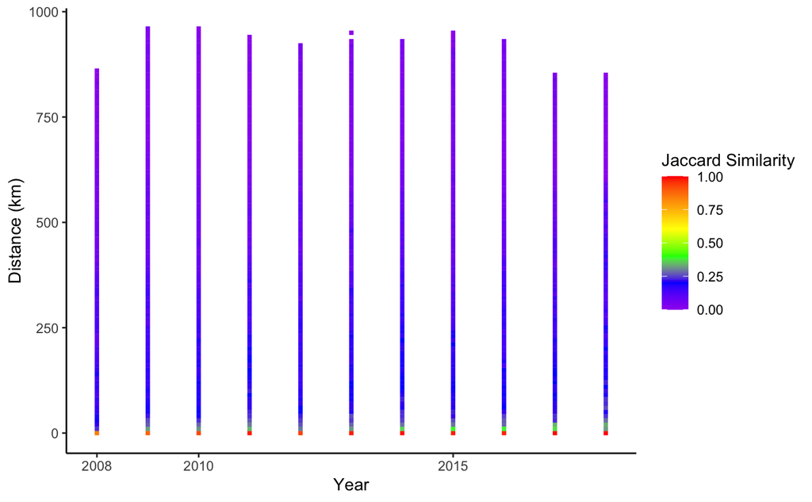

```r
#convert year to factor
setkey(gmex_distances_dissimilarities_allyears,year)
gmex_distances_dissimilarities_allyears[,year.f := as.factor(year)]

#jaccard similarity
(gmex_jaccard_heatmap <- ggplot(gmex_distances_dissimilarities_allyears_jaccard_rounded_allcombos,aes(as.factor(year),distance_km_10s, color = jaccard_similarity_mean_10s)) +
  geom_point(shape = 15, size = 1) +
  scale_color_gradientn(colors =
c("purple" ,"blue"  , "green" , "yellow" ,"orange", "red")
  ) +
scale_x_discrete(limits=levels(gmex_distances_dissimilarities_allyears_jaccard_rounded_allcombos$year.f), breaks = c("2008", "2010", "2015")) +
  labs(y = "Distance (km)", x = "Year", color = "Jaccard Similarity") +
  theme_classic())

ggsave(plot = gmex_jaccard_heatmap, path = here::here("figures","gmex"),file = "gmex_jaccard_heatmap.jpg")
ggsave(plot = gmex_jaccard_heatmap, path = here::here("figures","gmex"),file = "gmex_jaccard_heatmap.eps")
```

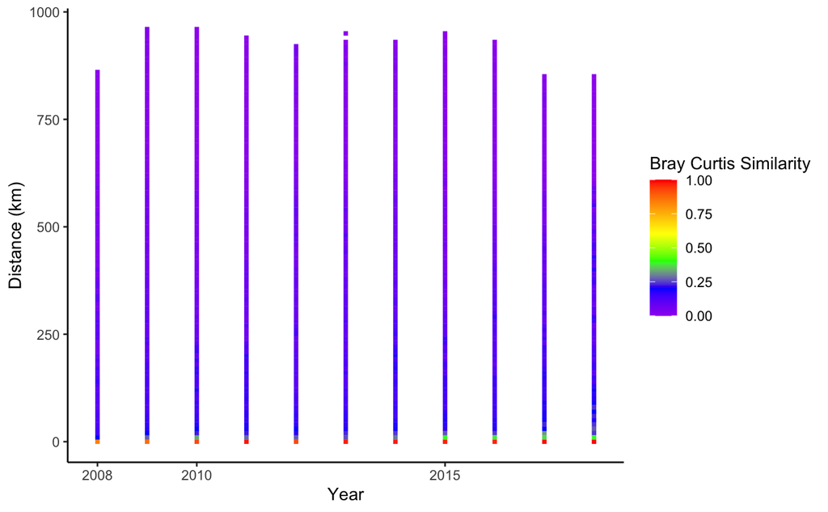

```r
#bray curtis similarity
(gmex_bray_heatmap <- ggplot(gmex_distances_dissimilarities_allyears_jaccard_rounded_allcombos,aes(as.factor(year),distance_km_10s, color = bray_similarity_mean_10s)) +
  geom_point(shape = 15, size = 1) +
  scale_color_gradientn(colors =
c("purple" ,"blue"  , "green" , "yellow" ,"orange", "red")
  ) +
  scale_x_discrete(limits=levels(gmex_distances_dissimilarities_allyears_jaccard_rounded_allcombos$year.f), breaks = c("2008", "2010", "2015")) +
  labs(y = "Distance (km)", x = "Year", color = "Bray Curtis Similarity") +
  theme_classic())

ggsave(plot = gmex_bray_heatmap, path = here::here("figures","gmex"),file = "gmex_bray_heatmap.jpg")
ggsave(plot = gmex_bray_heatmap, path = here::here("figures","gmex"),file = "gmex_bray_heatmap.eps")
```

Box plots

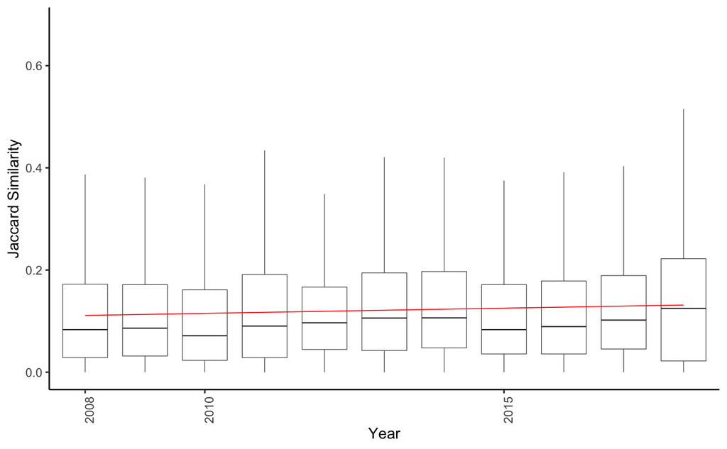

```r
#jaccard similarity
(gmex_jaccard_boxplot <- ggplot(gmex_distances_dissimilarities_allyears,aes(year.f,jaccard_similarity)) +
  geom_boxplot(outlier.shape = NA, lwd = 0.2) +
  labs(x="Year", y = "Jaccard Similarity") +
  scale_x_discrete(limits=levels(gmex_distances_dissimilarities_allyears$year.f), breaks = c("2008", "2010", "2015")) +
  geom_smooth(method = "lm", se=FALSE, color="red", aes(group=1), lwd = 0.3) +
  stat_regline_equation(label.x = 3, label.y = 32) +
  ylim(c(0,0.68)) +
  theme_classic() +
  theme(axis.text.x = element_text(angle = 90)))
```

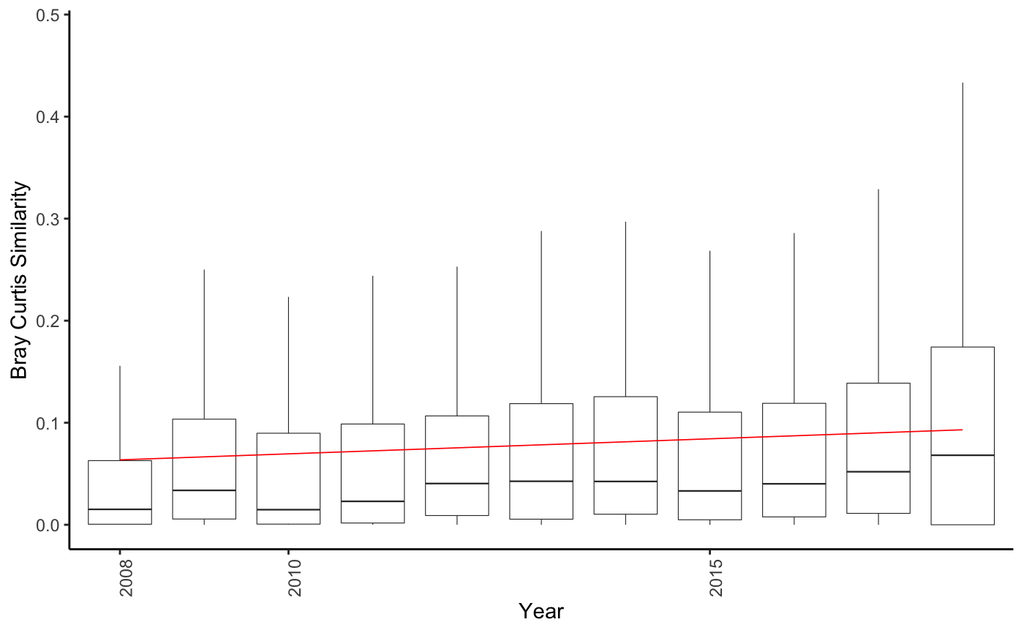

```r
#bray curtis similarity
(gmex_bray_boxplot <- ggplot(gmex_distances_dissimilarities_allyears,aes(year.f,bray_curtis_similarity)) +
  geom_boxplot(outlier.shape = NA, lwd = 0.2) +
  labs(x="Year", y = "Bray Curtis Similarity") +
  scale_x_discrete(limits=levels(gmex_distances_dissimilarities_allyears$year.f), breaks = c("2008", "2010", "2015")) +
  geom_smooth(method = "lm", se=FALSE, color="red", aes(group=1), lwd = 0.3) +
  stat_regline_equation(label.x = 3, label.y = 32) +
    ylim(c(0,0.48)) +
  theme_classic() +
  theme(axis.text.x = element_text(angle = 90)))
```

```r
#corresponding models
gmex_avg_jaccard_mod <- lm(data = gmex_distances_dissimilarities_allyears, formula = jaccard_similarity ~ as.numeric(year))

gmex_avg_bray_curtis_mod <- lm(data = gmex_distances_dissimilarities_allyears, formula = bray_curtis_similarity ~ as.numeric(year))

summary(gmex_avg_jaccard_mod)
```

```
Call:
lm(formula = jaccard_similarity ~ as.numeric(year), data = gmex_distances_dissimilarities_allyears)

Residuals:
     Min       1Q   Median       3Q      Max
-0.15596 -0.09930 -0.04128  0.05002  0.87695

Coefficients:
                   Estimate Std. Error t value Pr(>|t|)
(Intercept)      -5.8855125  0.4179696  -14.08   <2e-16 ***
as.numeric(year)  0.0029923  0.0002077   14.40   <2e-16 ***
---
Signif. codes:  0 ‘***’ 0.001 ‘**’ 0.01 ‘*’ 0.05 ‘.’ 0.1 ‘ ’ 1

Residual standard error: 0.1579 on 64675 degrees of freedom
Multiple R-squared:  0.003198,  Adjusted R-squared:  0.003182
F-statistic: 207.5 on 1 and 64675 DF,  p-value: < 2.2e-16
```

```r
summary(gmex_avg_bray_curtis_mod)
```

```
Call:
lm(formula = bray_curtis_similarity ~ as.numeric(year), data = gmex_distances_dissimilarities_allyears)

Residuals:
     Min       1Q   Median       3Q      Max
-0.12564 -0.08933 -0.06299  0.02049  0.91430

Coefficients:
                   Estimate Std. Error t value Pr(>|t|)
(Intercept)      -7.2051849  0.4463159  -16.14   <2e-16 ***
as.numeric(year)  0.0036309  0.0002218   16.37   <2e-16 ***
---
Signif. codes:  0 ‘***’ 0.001 ‘**’ 0.01 ‘*’ 0.05 ‘.’ 0.1 ‘ ’ 1

Residual standard error: 0.1686 on 64675 degrees of freedom
Multiple R-squared:  0.004125,  Adjusted R-squared:  0.00411
F-statistic: 267.9 on 1 and 64675 DF,  p-value: < 2.2e-16
```

Now, merge the previous two plots

```r
#pull out legend
gmex_legend_heatmaps <- get_legend(gmex_jaccard_heatmap + labs(color = "Similarity"))

gmex_merge <- plot_grid(gmex_jaccard_heatmap + theme(legend.position = "none", axis.title.x = element_blank(), axis.text.x = element_blank()) , gmex_bray_heatmap + theme(legend.position = "none", axis.title.x = element_blank(), axis.text.x = element_blank()), gmex_legend_heatmaps, gmex_jaccard_boxplot, gmex_bray_boxplot,  nrow = 2, ncol = 3, align = "hv", axis = "lb")
```

```
Removed 1155 rows containing non-finite values (stat_boxplot).`geom_smooth()` using formula 'y ~ x'
Removed 1155 rows containing non-finite values (stat_smooth).Removed 1155 rows containing non-finite values (stat_regline_equation).Removed 2215 rows containing non-finite values (stat_boxplot).`geom_smooth()` using formula 'y ~ x'
Removed 2215 rows containing non-finite values (stat_smooth).Removed 2215 rows containing non-finite values (stat_regline_equation).
```

```r
gmex_merge
```

[figure not shown]

```r
ggsave(gmex_merge, path = here::here("figures","gmex"), file = "gmex_heat_boxplot_merge.jpg", width = 8, height = 5, unit = "in")
ggsave(gmex_merge, path = here::here("figures","gmex"), file = "gmex_heat_boxplot_merge.eps", width = 8, height = 5, unit = "in")
```

###maybe i’ll do this later? maybe not At its heart, this graphic is just a ggplot() with a geom_raster() layer. The complication is, geom_raster() requires equally spaced points in both the x- and y-direction. The rest of this post is about how to make that happen.

Linear Interpolation

I interpolate in the distance direction first, because I think this is the better assumption: as you go down further away, a reasonable way to estimate the similarity at a distance which you did not measure is to draw a straight line between the similarity at the distance that you did measure. (Not great, but sure)

```r
estimate_jac_sim_by_year <- function(target_year, target_distance) {
  data_for_year <- gmex_distances_dissimilarities_allyears[year == target_year]

  # approx() is one way to do a linear interpolation
  approx(data_for_year$distance, data_for_year$jaccard_similarity, xout = target_distance)$y
}

estimate_jac_sim_by_year(1990, c(0,3000,300000))
```

Expand data inputs

```r
temp_interp_depth <- data.table(expand.grid(
  # the same years as gmex spring
  year = gmex_years,
  # ddistances can now be any value
  distance = seq(0, max(gmex_distances_dissimilarities_allyears$distance), by = 10))
)

temp_interp_depth[,jaccard_similarity_modeled := estimate_jac_sim_by_year(year,distance), year]
```

Visualize

```r
ggplot(temp_interp_depth,aes(year,distance, color = jaccard_similarity_modeled)) +
  geom_point() +
   scale_colour_gradient2(
    midpoint = 0.5,
    high = scales::muted("red"),
    low = scales::muted("blue")
  )
```

```r
estimate_jac_sim_by_distance <- function(target_distance, target_year) {
  data_for_distance <- temp_interp_depth[distance == target_distance,]
    setkey(data_for_distance, year)
  approx(data_for_distance$year, data_for_distance$jaccard_similarity_modeled, xout = target_year)$y
}

estimate_jac_sim_by_distance(
  target_distance = 1000000,
  target_year = c(1990,1998,2000)
)
```

Expand year grid

```r
jac_sim_raster <- data.table(expand.grid(
  # dates can now be any value
  year = seq(min(gmex_years), max(gmex_years), by = 1),
  # depths must be the same as in temp_interp_depth
  distance = unique(temp_interp_depth$distance))
)

jac_sim_raster[,jaccard_similarity_modeled := estimate_jac_sim_by_distance(distance,year),by = distance]
```

```r
ggplot(jac_sim_raster, aes(year, distance, fill = jaccard_similarity_modeled)) +
  geom_raster() +
  scale_fill_gradientn(colors =
c("purple" ,"blue"  , "green" , "yellow" ,"orange", "red")
  ) +
  coord_cartesian(expand = FALSE)
```